# Fun With the R Grid Package

Rick Dean

09/06/2020

```r
library(knitr)
library(grid)
```

The following R scripts and notes are sourced from [Fun With the R Grid Package](http://jse.amstat.org/v18n3/zhou.pdf), an article by Lutong Zhou and W. John Braun

# 1 Introduction

“We have found that the grid package is an interesting and surprisingly simple way to do a lot of things that are either difficult or impossible using the more traditional base graphics.”

“The grid package is an R package, developed by Paul Murrell in the 1990s.”

“We will describe the very basic ideas of the grid package, introducing viewports, editing graphic objects (grobs), and demonstrating how grid can be an alternative to traditional graphics. The second purpose of the paper is to demonstrate that, in addition to what is already available in the *lattice* package, the grid package offers flexibility which can be exploited in a variety of ways to visualize data.”

## 1.1 Using Viewports

Task: Create a viewport centered at (.5,.5), with width .9 and height .9 relative to the graphics window.

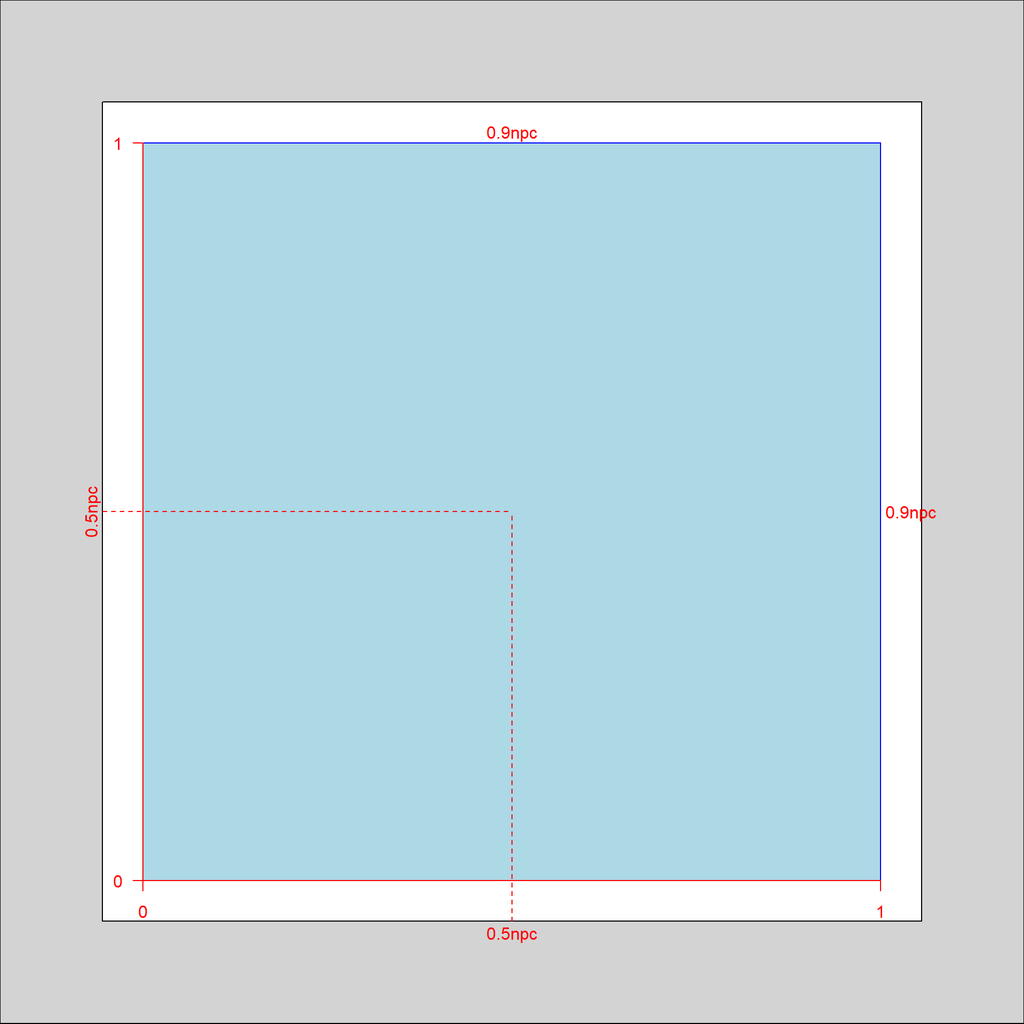

```r
main_vp <- grid::viewport(x=0.5,y=0.5,width = 0.9,height = 0.9,name = "main_vp")
grid::grid.show.viewport(v = main_vp)
```

A viewport name can be any string, but *grid* uses the reserved name “ROOT” for the top-level viewport.

Task: Create a new page, tell R to use the viewport by calling `grid::pushViewport()`, add rect and circle.

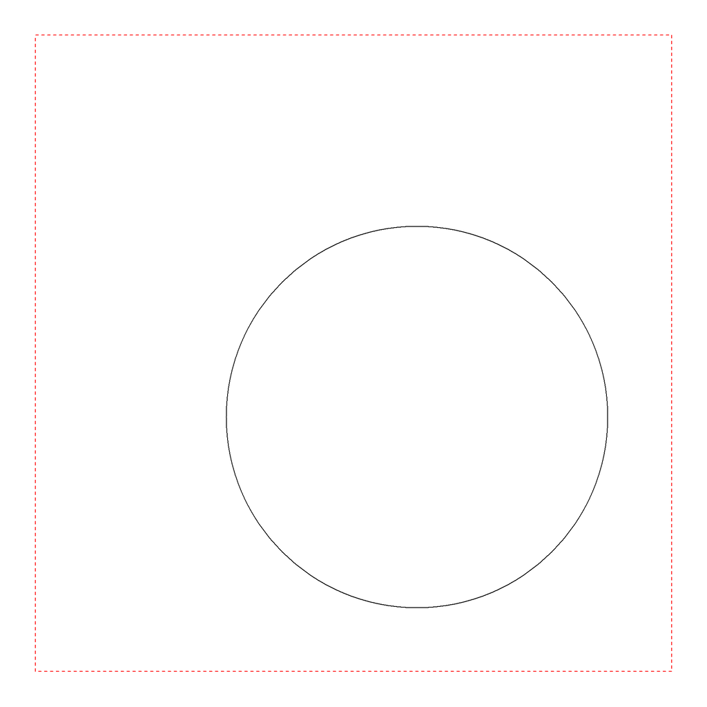

```r
grid::grid.newpage(recording = FALSE)
grid::pushViewport(main_vp)
grid::grid.rect(gp=gpar(lty="dashed",col="red"))
grid::grid.circle(x=0.6,y=0.4,r=0.3)
```

By default, the coordinates of the lower left corner of the viewport are (0,0), and the upper right corner has coordinates (1,1).

Task: Create a second(smaller) viewport “small_vp” to be placed within the “main_vp” viewport.

```r
small_vp <- viewport(x=0.5,y=0.75,width = 0.6,height = 0.3,name = "small_vp")
```

Task: Create a new page with “main_vp”, “small_vp” and place a circle and retangle in the “small_vp”.

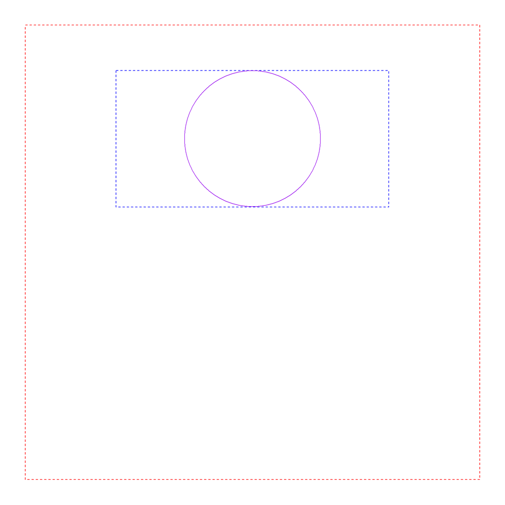

```r
grid::grid.newpage(recording = FALSE)
grid::pushViewport(main_vp)
grid::grid.rect(gp=gpar(lty="dashed",col="red"))
grid::pushViewport(small_vp)
grid::grid.rect(gp=gpar(lty="dashed",col="blue"))
grid::grid.circle(gp=gpar(col="purple"))
```

The specifications of “small_vp” `(x=0.5,y=0.75,width = 0.6,height = 0.3)` are relative to the viewport that it has been pushed into (i.e. “main_vp”).